# Clean Van Wiechen data JGZ

Iris Eekhout

2024-07-09

## Samenvatting

In deze notitie evalueren we het effect van het doorscoren (terugminnen en doorplussen) van item scores op de D-score. Hiermee willen we bekijken wat het effect is van doorscoren en het al dan niet toepassen van een leeftijdslimiet hierbij. We maken een vergelijking tussen drie versies van de data:

- Ruwe data, zoals verzameld
- Volledig doorscoren: een niet behaald item op voorgaande contactmomenten als 0 scoren, een behaald item op opvolgende contactmoment als 1 scoren.
- Doorscoren met leeftijdslimiet: doorscoren van items, maar binnen de leeftijdsrange waarop het kenmerk afgenomen kan worden.

Daarnaast handeren we een minimum van 3 item scores voor een D-score bepaling.

Voor het leeftijdslimiet per kenmerk gaan we uit van de leeftijd waarop het kenmerk wordt afgenomen volgens het van Wiechen schema. Dan is de ondergrens de leeftijd van het voorafgaand contactmoment, en de bovengrens de leeftijd van het opvolgend contactmoment. Deze leeftijdsgrens wordt alleen toegepast voor het doorscoren (terugminnen en doorplussen), geregistreerde data blijft behouden.

De D-scores (daz) bepaald in deze 3 versies van de data wordt (1) opzichzelf geevalueerd; (2) onderling vergeleken; en (3) extern gevalideerd door de relatie met zwangerschapsduur te bekijken.

*Conclusies*

- Vellodig doorscoren zorgt voor een grote toename in item scores per data-regel.
- Volledig doorscoren zorgt voor een lagere daz in vergelijking met de ruwe data.
- Doorscoren met leeftijdslimiet zorgt voor soms een lagere en some een hogere daz.
- De relatie met zwangerschapsduur is het sterkts voor de daz obv doorscoren met leeftijdslimiet, maar de verschillen onderling zijn klein.

## Example data

Volledige SMOCK data nu gebruikt.

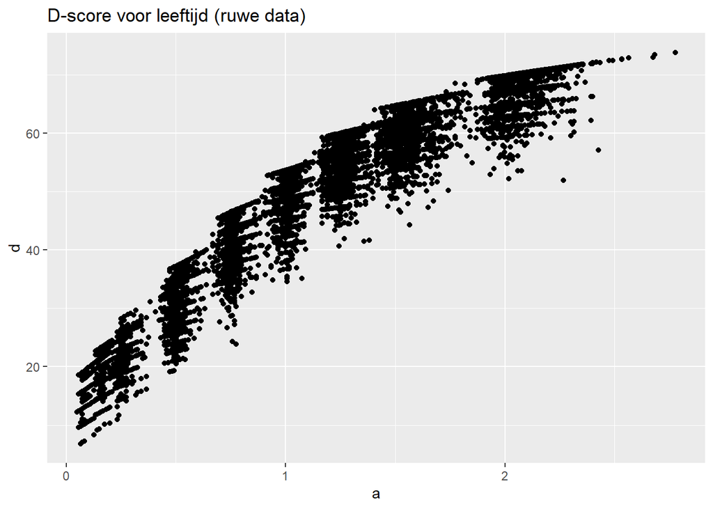

```r
#D-score berekenen met cleaningstappen JGZ data
vwd <- childdevdata::gcdg_nld_smocc %>%
  mutate(agemos = agedays/365.25 * 12,
         age = agemos / 12)

#set.seed(62548)
#subselection <- sample(unique(vwd$subjid), 100)

#vwd <- vwd %>% filter(subjid %in% subselection)

dgsed <- vwd %>%
  dscore::dscore(data = .,
                 items = colnames(vwd)[grepl("^ddi",colnames(vwd))],
                 itembank = dscore::builtin_itembank[dscore::builtin_itembank$key == "gsed2212",],
                 key = "gsed2212",
                 population = "dutch")

dgsedc <- dgsed %>% filter(n >= 3)

ggplot(dgsedc, aes(a, d))+
  geom_point() +
  ggtitle("D-score voor leeftijd (ruwe data)")
```

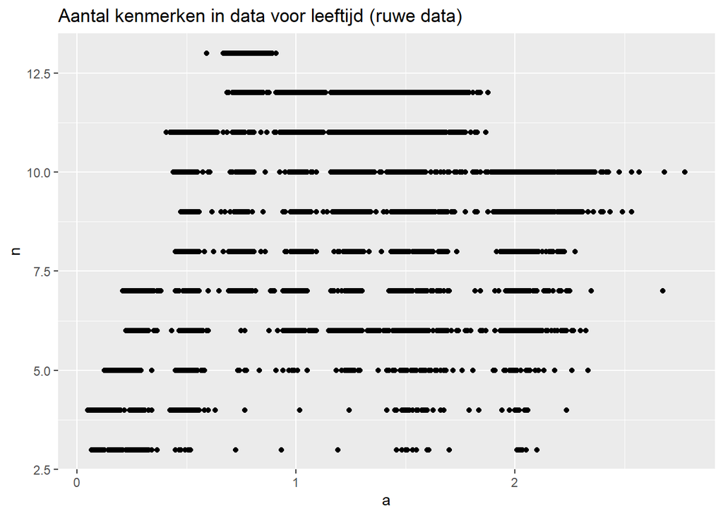

```r
ggplot(dgsedc, aes(a, n))+
  geom_point() +
  ggtitle("Aantal kenmerken in data voor leeftijd (ruwe data)")
```

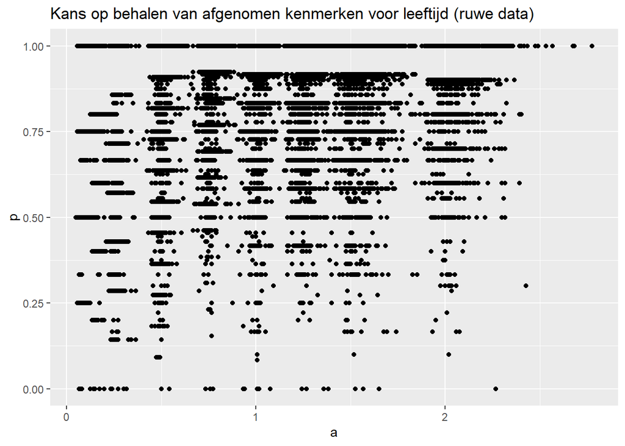

```r
ggplot(dgsedc, aes(a, p))+
  geom_point() +
  ggtitle("Kans op behalen van afgenomen kenmerken voor leeftijd (ruwe data)")
```

## Doorplussen en terugminnen als gegevens van omliggende contactmomenten beschikbaar zijn.

Van wiechen items terugminnen en doorplussen, dus wanneer een kenmerk niet behaald is, op voorgaande contactmomenten dit kenmerk ook als 0 scoren (tot een minimum leeftijd voor het kenmerk). En wanneer een kenmerk is behaald, deze op volgende contactmomenten als 1 te scoren (tot een maximum leeftijd voor het kenmerk).

- Doorscoren alleen: alle items doorplussen en teruggeminnen tot zover er data / contactmomenten zijn. Dan zijn er zeker item responsen die praktisch niet kunnen voorkomen.
- Doorscoren met limiet: doorplussen en terugminnen tot bepaalde leeftijdsgrenzen per kenmerk. Dus voor elk kenmerk geld een leeftijdsrange waarop deze doorgescoord mag worden.

**Leeftijdsrange per kenmerk**

```r
## age limit is next cm age
cm_max <- data.frame(
  month =   c(1, 2, 3, 6,  9, 12, 15, 18, 24, 30, 36, 42, 48, 55),
  max_lft = c(2, 3, 6, 9, 12, 15, 18, 24, 30, 36, 42, 48, 55, 78),
  min_lft = c(0, 1, 2, 3,  6,  9,  12, 15, 18, 24, 30, 36, 42, 48 )
)

itemtableVWO <- dscoreddi::itemtableVWO %>% select(item, labelNL, occ, month) %>%
  left_join(cm_max, by = "month") %>% select(item, labelNL, occ, month, min_lft, max_lft)

itemtableVWO %>% kable()
```

| item | labelNL | occ | month | min_lft | max_lft |
| --- | --- | --- | --- | --- | --- |
| ddifmd001 | Ogen fixeren | 1 | 1 | 0 | 2 |
| ddifmd002 | Volgt met ogen en hoofd | 2 | 2 | 1 | 3 |
| ddifmd003 | Handen af en toe openen | 3 | 3 | 2 | 6 |
| ddifmm004 | Kijkt naar eigen handen | 3 | 3 | 2 | 6 |
| ddifmd005 | Speelt met handen middenvoor | 4 | 6 | 3 | 9 |
| ddigmd006 | Pakt in rugligging voorwerp binnen bereik | 4 | 6 | 3 | 9 |
| ddifmd007 | Pakt blokje over | 5 | 9 | 6 | 12 |
| ddifmd008 | Houdt blokje vast, pakt er nog een in andere hand | 5 | 9 | 6 | 12 |
| ddifmm009 | Speelt met beide voeten | 5 | 9 | 6 | 12 |
| ddifmd010 | Pakt propje met duim en wijsvinger | 6 | 12 | 9 | 15 |
| ddifmd011 | Doet blokje in/uit doos | 7 | 15 | 12 | 18 |
| ddifmm012 | Speelt geven en nemen (M) | 7 | 15 | 12 | 18 |
| ddifmd013 | Stapelt 2 blokjes - rl | 8 | 18 | 15 | 24 |
| ddifmm014 | Gaat op onderzoek uit (M) | 8 | 18 | 15 | 24 |
| ddifmd015 | Stapelt 3 blokjes - rl | 9 | 24 | 18 | 30 |
| ddifmm016 | Doet anderen na (M) | 9 | 24 | 18 | 30 |
| ddifmd017 | Stapelt 6 blokjes | 10 | 30 | 24 | 36 |
| ddifmd018 | Plaatst ronde vorm in stoof | 10 | 30 | 24 | 36 |
| ddifmm019 | Trekt kledingstuk uit (M) | 10 | 30 | 24 | 36 |
| ddifmd020 | Bouwt vrachtauto na | 11 | 36 | 30 | 42 |
| ddifmd021 | Plaatst 3 vormen in stoof | 11 | 36 | 30 | 42 |
| ddifmd022 | Tekent verticale lijn na | 11 | 36 | 30 | 42 |
| ddifmd023 | Bouwt brug na | 12 | 42 | 36 | 48 |
| ddifmd024 | Plaatst 4 vormen in stoof | 12 | 42 | 36 | 48 |
| ddifmm025 | Trekt eigen kledingstuk aan (M) | 12 | 42 | 36 | 48 |
| ddifmd027 | Houdt potlood met vingers vast | 13 | 48 | 42 | 55 |
| ddifmd026 | Tekent cirkel na | 13 | 48 | 42 | 55 |
| ddicmm029 | Reageert op toespreken (M) | 1 | 1 | 0 | 2 |
| ddicmm030 | Lacht terug (M) | 2 | 2 | 1 | 3 |
| ddicmm031 | Maakt geluiden terug (M) | 3 | 3 | 2 | 6 |

[output cut: 59 more lines]

**Doorscoren van de items in de data**

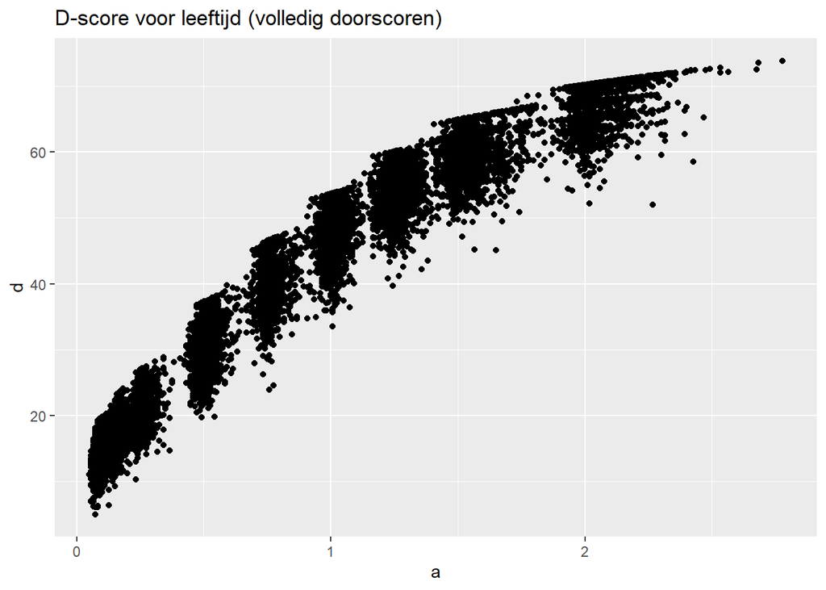

```r
doorscoren <- function(age, item){
  #terugminnen
  if(any(item == 0, na.rm = T)){
    age0 = max(age[which(item == 0)])
    #terugminnen
    item = ifelse(age < age0, 0, item)
    #tot minimum leeftijd

  }
  if(any(item == 1, na.rm = T)){
    age1 = min(age[which(item ==1)])
    item = ifelse(age > age1, 1, item)
  }
  item
}


# per "id", leeftijd in maanden staat in kolom "agemos"
vwd_add <-
  vwd %>%
  group_by(subjid) %>%
  mutate_at(vars(starts_with("ddi")),
            ~doorscoren(agemos, .)) %>% ungroup()

#dscore bepalen obv doorgescoorde items
dgsed_add <- vwd_add %>%
  dscore::dscore(data = .,
                 items = colnames(vwd_add)[grepl("^ddi",colnames(vwd_add))],
                 itembank = dscore::builtin_itembank[dscore::builtin_itembank$key == "gsed2212",],
                 key = "gsed2212",
                 population = "dutch")


dgsed_addc <- dgsed_add %>% filter(n >= 3)

ggplot(dgsed_addc, aes(a, d))+
  geom_point() +
  ggtitle("D-score voor leeftijd (volledig doorscoren)")
```

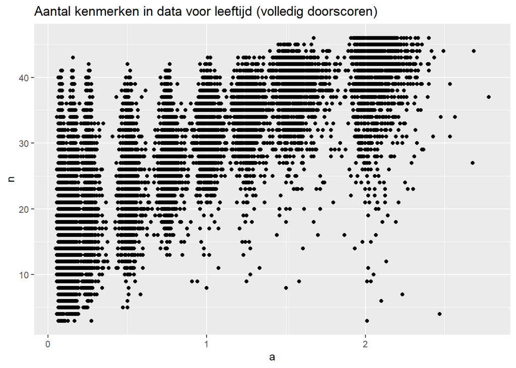

```r
ggplot(dgsed_addc, aes(a, n))+
  geom_point() +
  ggtitle("Aantal kenmerken in data voor leeftijd (volledig doorscoren)")
```

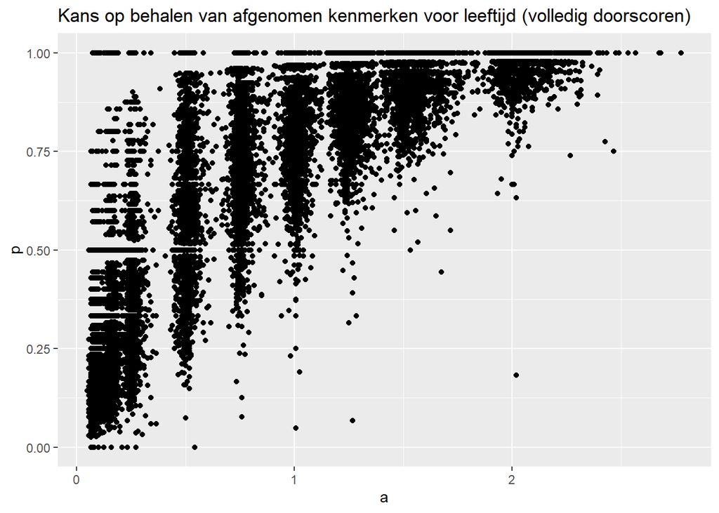

```r
ggplot(dgsed_addc, aes(a, p))+
  geom_point() +
  ggtitle("Kans op behalen van afgenomen kenmerken voor leeftijd (volledig doorscoren)")
```

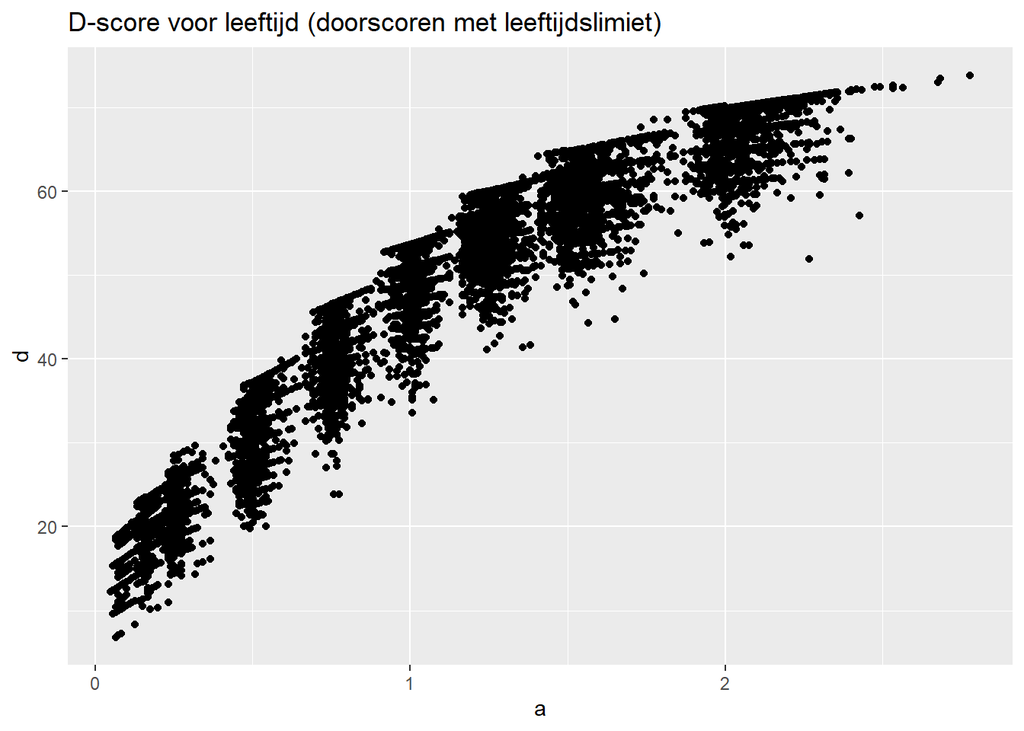

```r
doorscoren_limit <- function(age, item, itname, itemtable){

  minage <- itemtable |> filter(item == itname) |> pull(min_lft)
  maxage <- itemtable |> filter(item == itname) |> pull(max_lft)

  if(any(item == 0, na.rm = T)){
    age0 = max(age[which(item == 0)])
    item = ifelse(age < age0 & age > minage, 0, item)

  }
  if(any(item == 1, na.rm = T)){
    age1 = min(age[which(item ==1)])
    item = ifelse(age > age1 & age < maxage, 1, item)
  }
  item
}


# per "id", leeftijd in maanden staat in kolom "agemos"
vwd_add_limit <-
  vwd %>%
  group_by(subjid) %>%
  mutate(across(starts_with("ddi"),
            ~doorscoren_limit(agemos, .,itname = cur_column(), itemtable = itemtableVWO))) %>% ungroup()

#dscore bepalen obv doorgescoorde items
dgsed_add_limit <- vwd_add_limit %>%
  dscore::dscore(data = .,
                 items = colnames(vwd_add_limit)[grepl("^ddi",colnames(vwd_add_limit))],
                 itembank = dscore::builtin_itembank[dscore::builtin_itembank$key == "gsed2212",],
                 key = "gsed2212",
                 population = "dutch")

dgsed_add_limitc <- dgsed_add_limit %>% filter(n >= 3)


ggplot(dgsed_add_limitc, aes(a, d))+
  geom_point() +
  ggtitle("D-score voor leeftijd (doorscoren met leeftijdslimiet)")
```

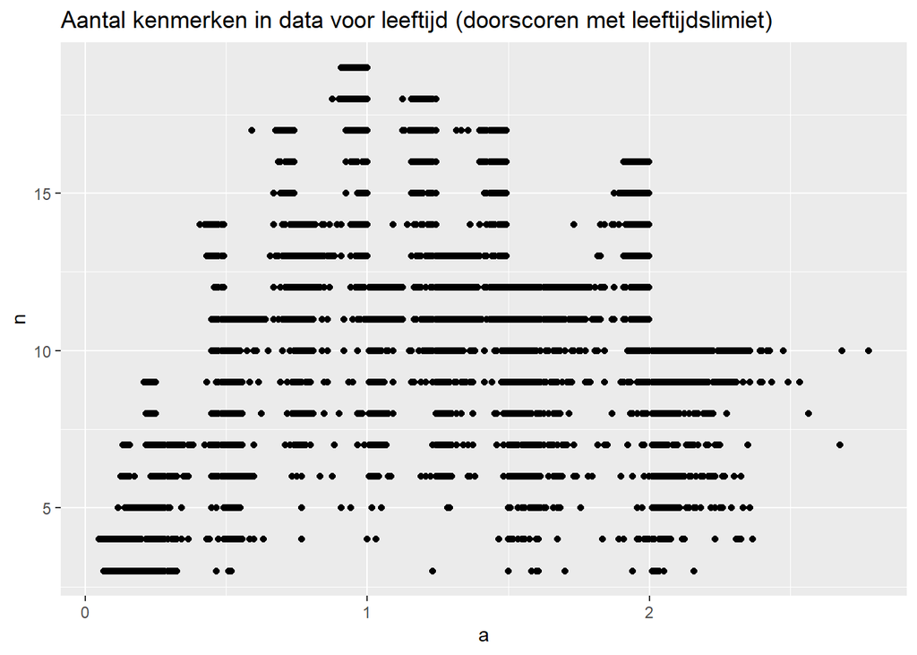

```r
ggplot(dgsed_add_limitc, aes(a, n))+
  geom_point() +
  ggtitle("Aantal kenmerken in data voor leeftijd (doorscoren met leeftijdslimiet)")
```

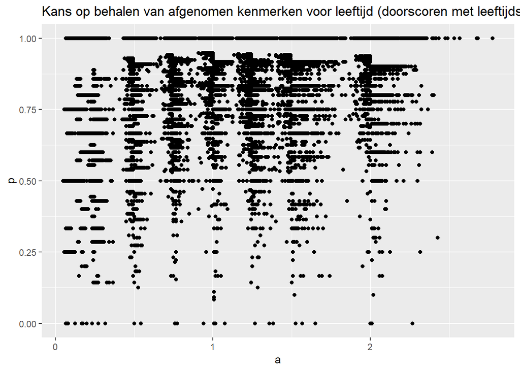

```r
ggplot(dgsed_add_limitc, aes(a, p))+
  geom_point() +
  ggtitle("Kans op behalen van afgenomen kenmerken voor leeftijd (doorscoren met leeftijdslimiet)")
```

## Vergelijking van resultaten

- *raw* = de D-scores op basis van de verzamelde data.
- *doorscoren* = de D-scores op basis van doorplussen en terugminnen, zonder verdere leeftijdsrestricties
- *door_limit* = de D-scores op basis van doorplussen en terugminnen met zowel een minimum, als een maximum leeftijd waarop elk kenmerk mee mag doen.

```r
dcomp <-
bind_rows(dgsed %>% mutate(clean = "raw"),
          dgsed_add %>% mutate(clean = "doorscoren"),
          dgsed_add_limit %>% mutate(clean = "door_limit")
) %>% filter(n >= 3)
```

**Aantal kenmerken dat meetelt voor de score per cleaning methode**

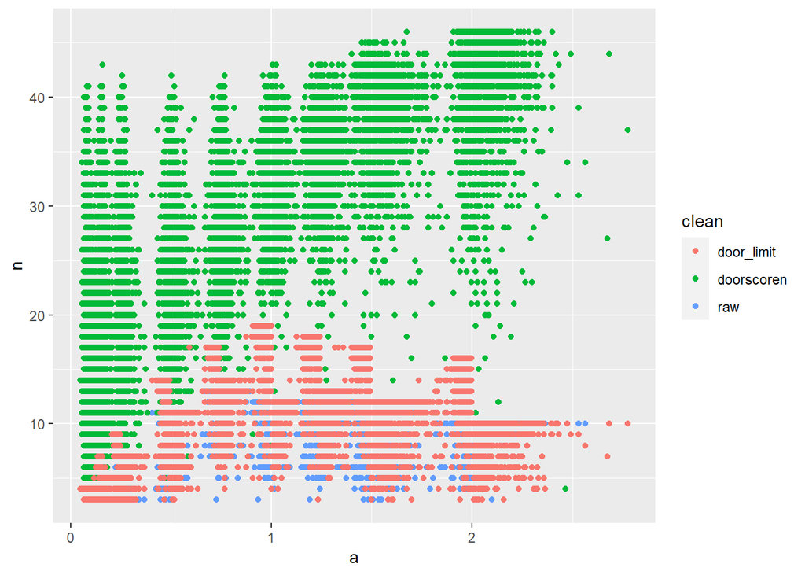

```r
ggplot(dcomp, aes(a, n, color = clean))+
  geom_point()
```

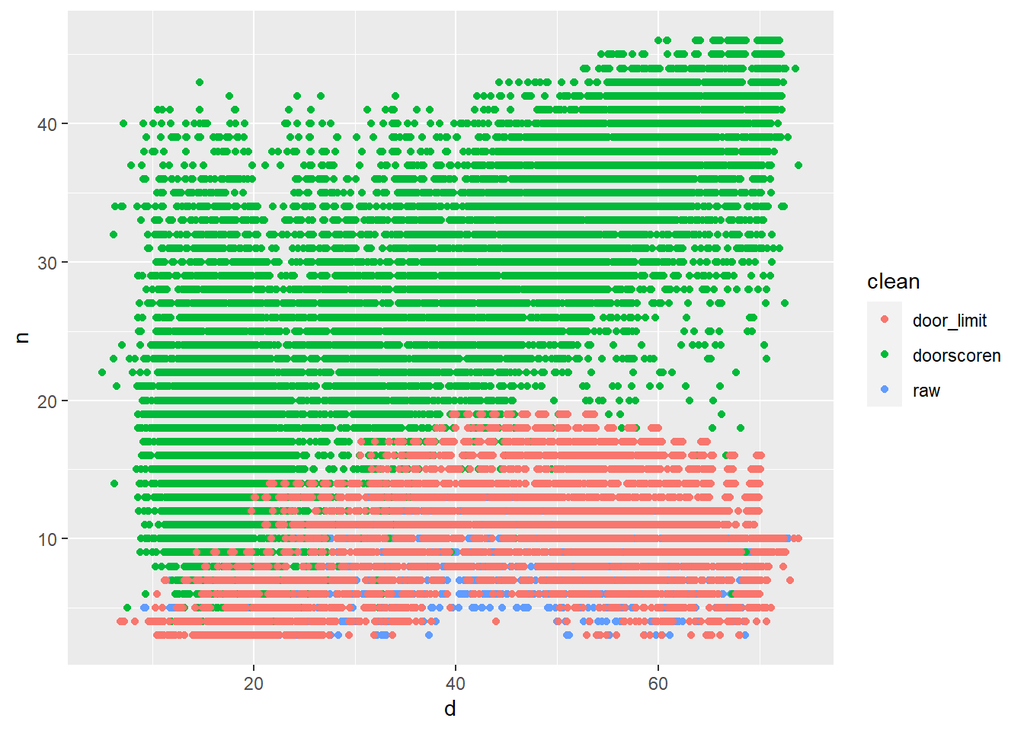

```r
ggplot(dcomp, aes(d, n, color = clean))+
  geom_point()
```

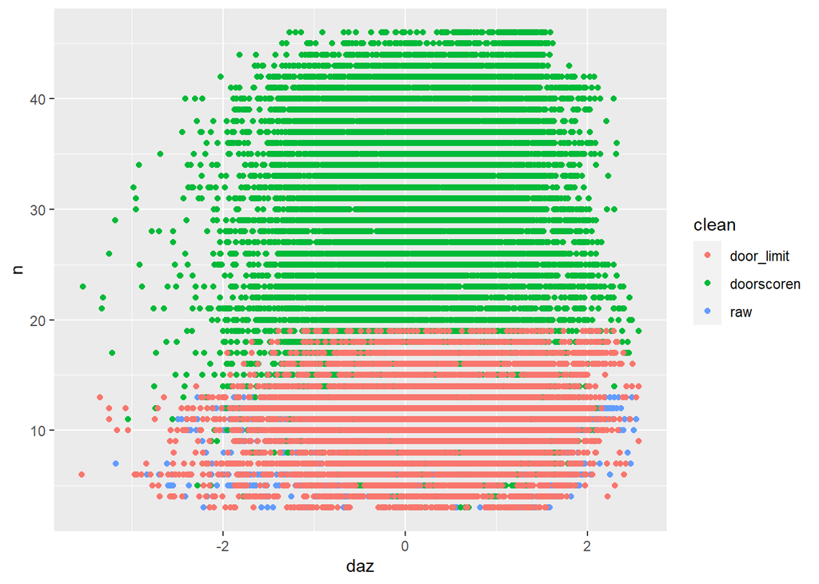

```r
ggplot(dcomp, aes(daz, n, color = clean))+
  geom_point()
```

**D-score schatting en kans op behalen van kenmerken**

De impact op de D-score inschatting lijkt niet erg groot.

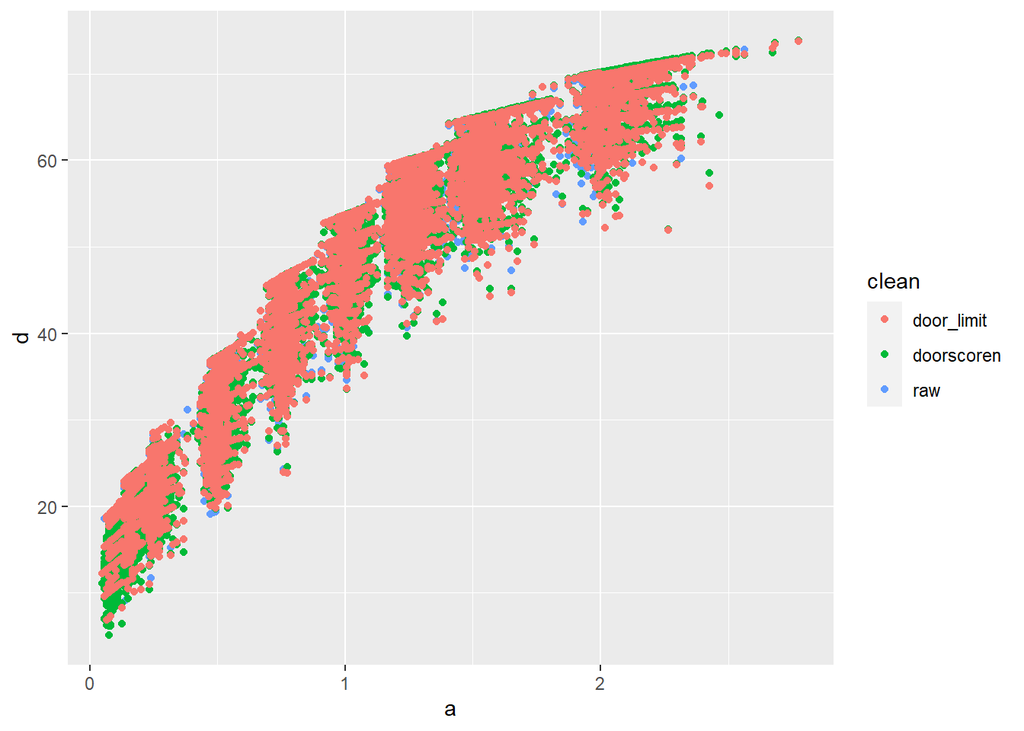

```r
ggplot(dcomp, aes(a, d, color = clean))+
  geom_point()
```

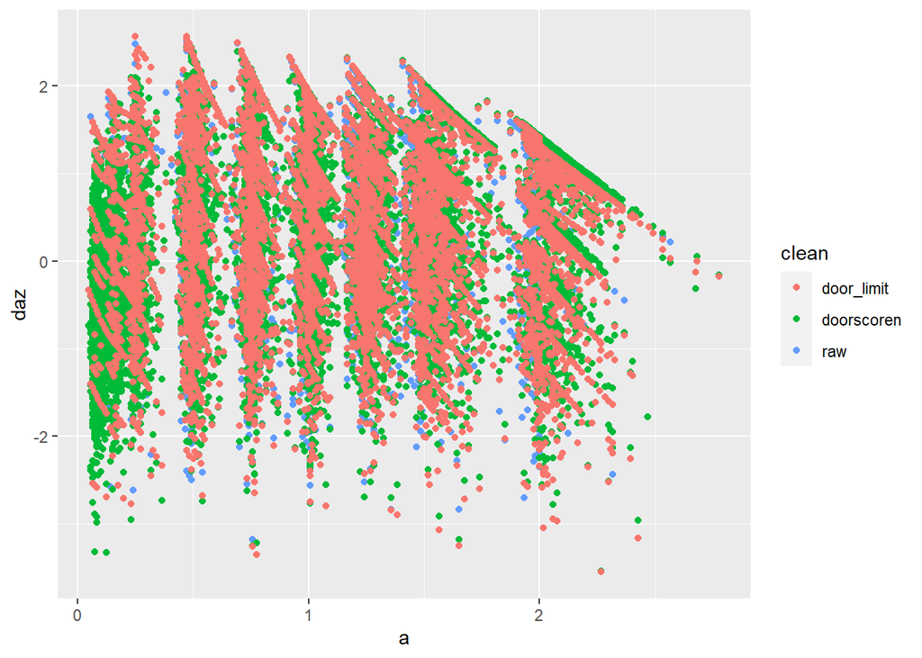

```r
ggplot(dcomp, aes(a, daz, color = clean))+
  geom_point()
```

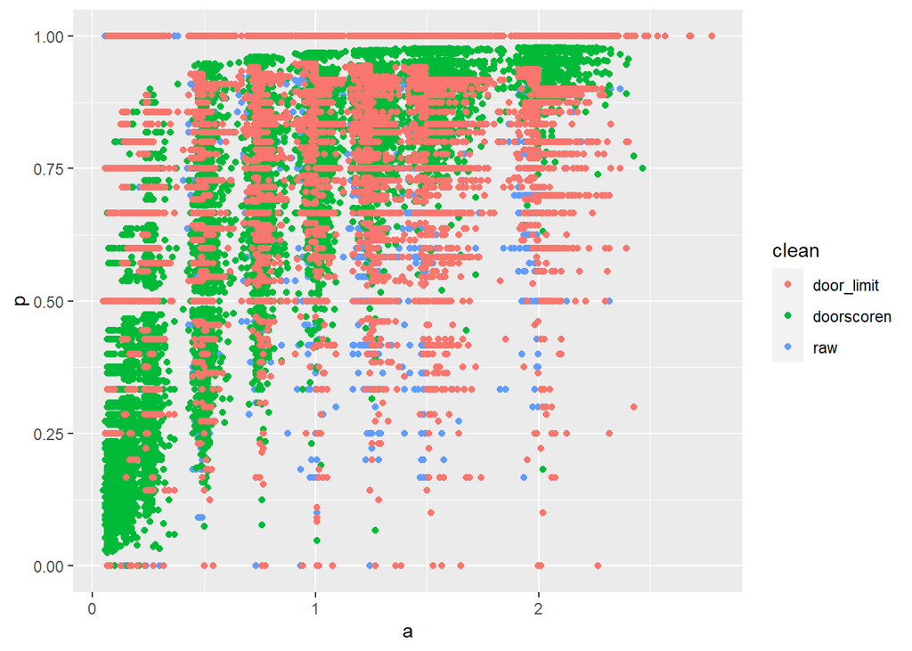

```r
ggplot(dcomp, aes(a, p, color = clean))+
  geom_point()
```

**Analyse van verschil DAZ**

Voor deze vergelijking is de selectie voor minimaal aantal kenmerken voor een D-score (n >= 3), gemaakt obv de ruwe data.

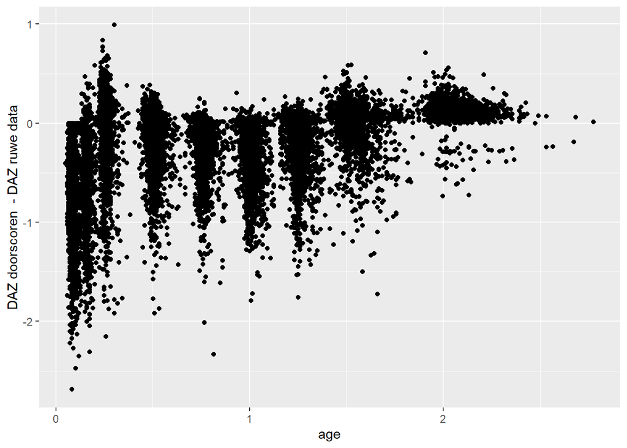

```r
compare <- data.frame(
                 daz_door_raw = dgsed_add$daz - dgsed$daz,
                 daz_doorlim_raw = dgsed_add_limit$daz - dgsed$daz,
                 daz_raw = dgsed$daz,
                 daz_door = dgsed_add$daz,
                 daz_doorlim = dgsed_add_limit$daz,
                 age = dgsed$a,
                 nraw = dgsed$n) %>% filter(nraw >= 3)

ggplot(compare, aes(age, daz_door_raw) )+
  geom_point()+
  ylab("DAZ doorscoren  - DAZ ruwe data")
```

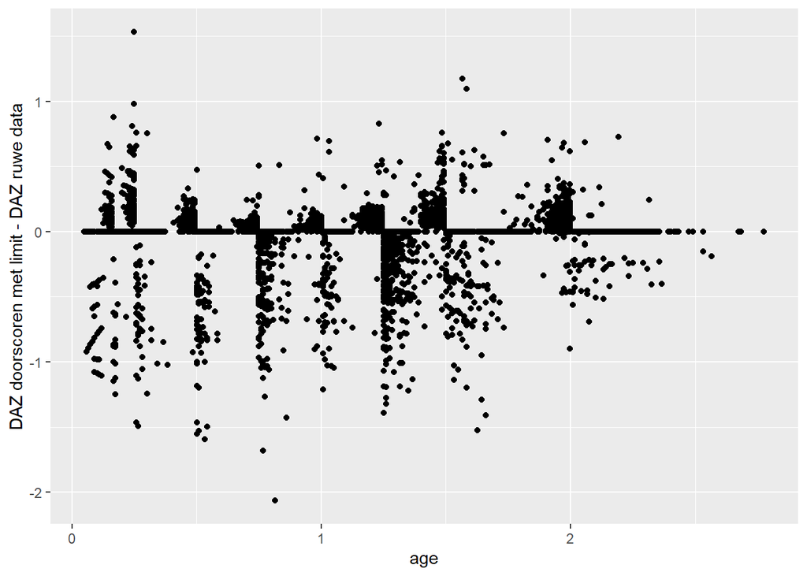

```r
ggplot(compare, aes(age, daz_doorlim_raw) )+
  geom_point()+
  ylab("DAZ doorscoren met limit - DAZ ruwe data")
```

**Directe vergelijking van DAZ**

Door het doorscoren wordt de DAZ iets lager.

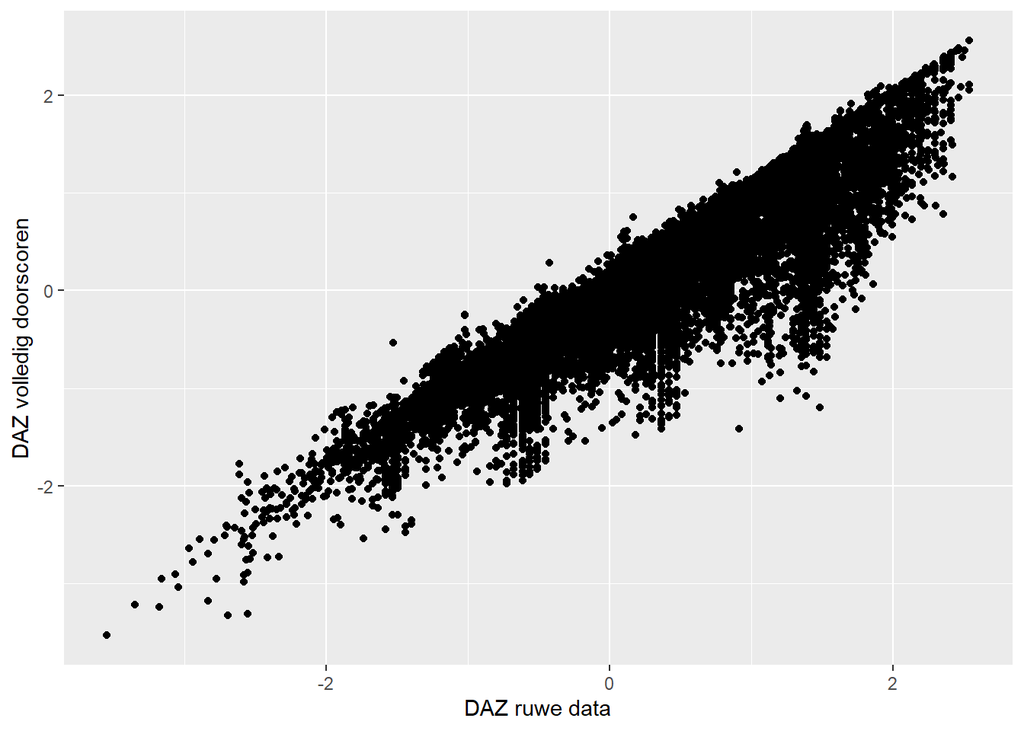

```r
ggplot(compare,
       aes(daz_raw, daz_door))+
       geom_point()+
       xlab ("DAZ ruwe data")+ ylab("DAZ volledig doorscoren")
```

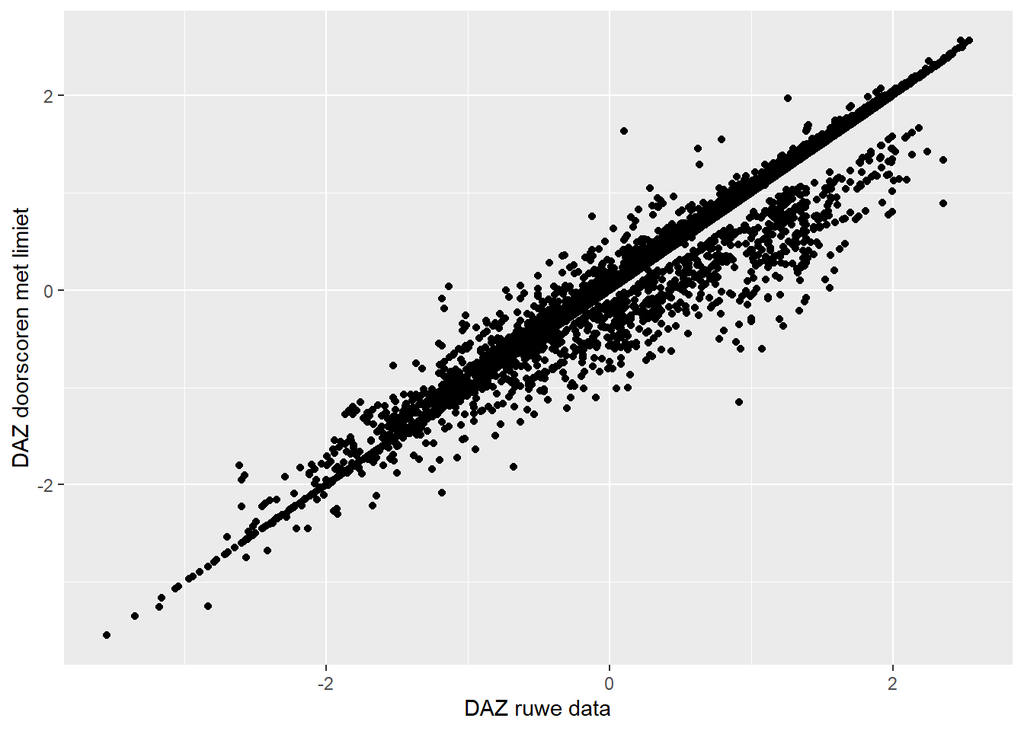

```r
ggplot(compare,
       aes(daz_raw, daz_doorlim))+
       geom_point()+
       xlab ("DAZ ruwe data")+ ylab("DAZ doorscoren met limiet")
```

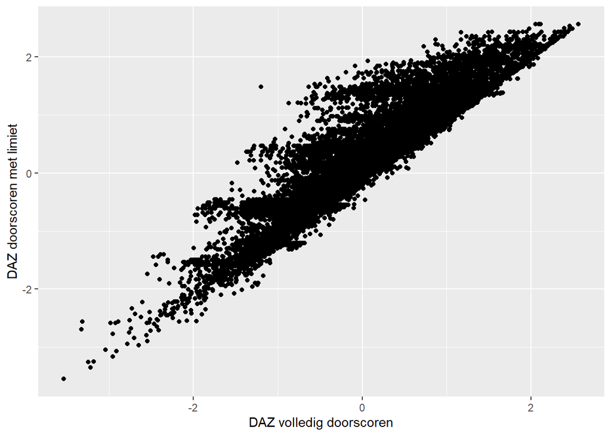

```r
ggplot(compare,
       aes(daz_door, daz_doorlim))+
       geom_point()+
       xlab ("DAZ volledig doorscoren")+ ylab("DAZ doorscoren met limiet")
```

## Regressie D-score en gestational age

**Gestational age**

Hier lijkt doorscoren met leeftijdslimieten het meeste variantie te verklaren en de sterkste associatie te hebben.

*Ruwe data*

```r
vwd_d <- dgsed %>% bind_cols(vwd) %>% filter(n >= 3)
lm(daz ~ gagebrth, data = vwd_d) %>% summary
```

```
##
## Call:
## lm(formula = daz ~ gagebrth, data = vwd_d)
##
## Residuals:
##     Min      1Q  Median      3Q     Max
## -3.7444 -0.7065  0.0148  0.7609  2.3154
##
## Coefficients:
##               Estimate Std. Error t value Pr(>|t|)
## (Intercept) -3.7535425  0.1719905  -21.82   <2e-16 ***
## gagebrth     0.0148456  0.0006202   23.94   <2e-16 ***
## ---
## Signif. codes:  0 '***' 0.001 '**' 0.01 '*' 0.05 '.' 0.1 ' ' 1
##
## Residual standard error: 0.9395 on 15329 degrees of freedom
##   (136 observations deleted due to missingness)
## Multiple R-squared:  0.03603,    Adjusted R-squared:  0.03597
## F-statistic:   573 on 1 and 15329 DF,  p-value: < 2.2e-16
```

*Volledig doorscoren*

```r
vwd_add <- dgsed_add %>% bind_cols(vwd) %>% filter(n >= 3)
lm(daz ~ gagebrth, data = vwd_add) %>% summary
```

```
##
## Call:
## lm(formula = daz ~ gagebrth, data = vwd_add)
##
## Residuals:
##     Min      1Q  Median      3Q     Max
## -3.4749 -0.6239 -0.0439  0.6386  2.5261
##
## Coefficients:
##               Estimate Std. Error t value Pr(>|t|)
## (Intercept) -3.8623319  0.1531990  -25.21   <2e-16 ***
## gagebrth     0.0142866  0.0005524   25.86   <2e-16 ***
## ---
## Signif. codes:  0 '***' 0.001 '**' 0.01 '*' 0.05 '.' 0.1 ' ' 1
##
## Residual standard error: 0.8674 on 16521 degrees of freedom
##   (5 observations deleted due to missingness)
## Multiple R-squared:  0.03891,    Adjusted R-squared:  0.03886
## F-statistic: 668.9 on 1 and 16521 DF,  p-value: < 2.2e-16
```

*Doorscoren met leeftijdslimiet*

```r
vwd_add_limit <- dgsed_add_limit %>% bind_cols(vwd) %>% filter(n >= 3)
lm(daz ~ gagebrth, data = vwd_add_limit) %>% summary
```

```
##
## Call:
## lm(formula = daz ~ gagebrth, data = vwd_add_limit)
##
## Residuals:
##     Min      1Q  Median      3Q     Max
## -3.7607 -0.6674  0.0082  0.7369  2.3165
##
## Coefficients:
##               Estimate Std. Error t value Pr(>|t|)
## (Intercept) -3.8189204  0.1648791  -23.16   <2e-16 ***
## gagebrth     0.0151527  0.0005946   25.49   <2e-16 ***
## ---
## Signif. codes:  0 '***' 0.001 '**' 0.01 '*' 0.05 '.' 0.1 ' ' 1
##
## Residual standard error: 0.9171 on 15960 degrees of freedom
##   (5 observations deleted due to missingness)
## Multiple R-squared:  0.03911,    Adjusted R-squared:  0.03905
## F-statistic: 649.5 on 1 and 15960 DF,  p-value: < 2.2e-16
```